# Actividad Extra 1

2024-04-08

# *Equipo 1*

- Gabriela Cantú Sánchez A01735256
- Alexa Mariana Marin Villar A00831342
- Ana Estefanía López Alanis A01284416
- Astrid Paola Gonzalez Diaz A00830114

# **SPATIAL PANEL DATA ANALYSIS**

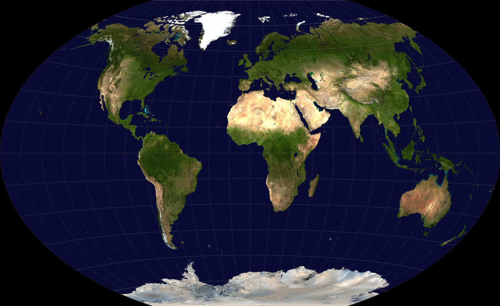

## **Modelo de regresion no espacial**

```r
panel_model<-new_fdi_real_mxn ~ pop_density + real_wage + patents_rate + region_b

# estimate panel regression model
non_spatial_panel_model <- plm(panel_model, data= nearshoring, model = "within", effect = "twoways")
summary(non_spatial_panel_model)
```

```
## Twoways effects Within Model
##
## Call:
## plm(formula = panel_model, data = nearshoring, effect = "twoways",
##     model = "within")
##
## Balanced Panel: n = 32, T = 16, N = 512
##
## Residuals:
##      Min.   1st Qu.    Median   3rd Qu.      Max.
## -51740.44  -2506.88   -571.44   1806.50  48963.67
##
## Coefficients:
##              Estimate Std. Error t-value Pr(>|t|)
## pop_density    37.951     20.845  1.8206  0.06931 .
## real_wage      30.261     33.642  0.8995  0.36886
## patents_rate -567.302    240.201 -2.3618  0.01860 *
## ---
## Signif. codes:  0 '***' 0.001 '**' 0.01 '*' 0.05 '.' 0.1 ' ' 1
##
## Total Sum of Squares:    2.1112e+10
## Residual Sum of Squares: 2.0718e+10
## R-Squared:      0.018655
## Adj. R-Squared: -0.085427
## F-statistic: 2.92744 on 3 and 462 DF, p-value: 0.033417
```

### **Matriz de conectividad**

```r
swm  <- poly2nb(mx_state_map, queen=T)
summary(swm)
```

```
## Neighbour list object:
## Number of regions: 32
## Number of nonzero links: 138
## Percentage nonzero weights: 13.47656
## Average number of links: 4.3125
## Link number distribution:
##
## 1 2 3 4 5 6 7 8 9
## 1 6 6 6 5 2 3 2 1
## 1 least connected region:
## 31 with 1 link
## 1 most connected region:
## 8 with 9 links
```

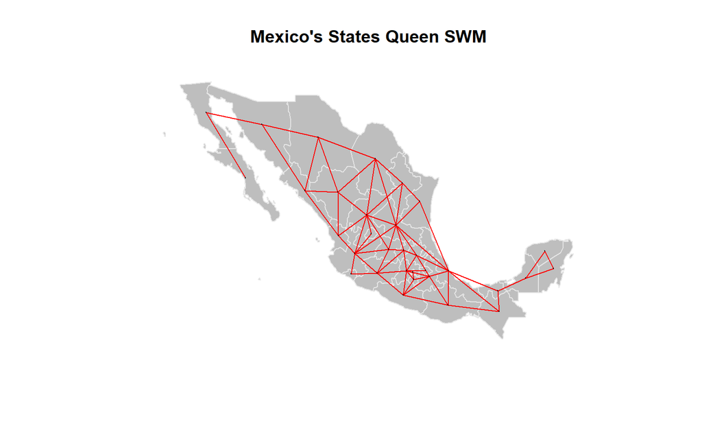

```r
sswm <- nb2listw(swm, style="W", zero.policy = TRUE)

mx_state_map_a <- as(mx_state_map, "Spatial")
mx_state_map_centroid <- coordinates(mx_state_map_a)
plot(mx_state_map_a,border="blue",axes=FALSE,las=1, main="Mexico's States Queen SWM")
plot(mx_state_map_a,col="grey",border=grey(0.9),axes=T,add=T)
plot(sswm,coords=mx_state_map_centroid,pch=19,cex=0.1,col="red",add=T)
```

## **Modelo de regresion espacial**

```r
# estimate spatial panel regression model
spatial_panel_model <- pspatfit(formula = panel_model, data = nearshoring, listw = sswm, demean = FALSE, eff_demean = "twoways", type = "sar", index = c("state", "year"))
```

```
##
## Fitting Model...
```

```
##
##  Time to fit the model:  0.28 seconds
```

```r
summary(spatial_panel_model)
```

```
##
##  Call
## pspatfit(formula = panel_model, data = nearshoring, listw = sswm,
##     type = "sar", demean = FALSE, eff_demean = "twoways", index = c("state",
##         "year"))
##
##  Parametric Terms
##                  Estimate  Std. Error t value  Pr(>|t|)
## (Intercept)  -8.7272e+03  3.1924e+03 -2.7338  0.006481 **
## pop_density   5.2090e+00  4.1101e-01 12.6735 < 2.2e-16 ***
## real_wage     4.3436e+01  9.9398e+00  4.3699 1.509e-05 ***
## patents_rate  1.7383e+02  1.9905e+02  0.8733  0.382913
## region_b     -1.4057e+02  2.5830e+02 -0.5442  0.586533
## rho           5.3855e-02  5.8387e-02  0.9224  0.356768
## ---
## Signif. codes:  0 '***' 0.001 '**' 0.01 '*' 0.05 '.' 0.1 ' ' 1
##
##  Goodness-of-Fit
##
##  EDF Total:      6
##  Sigma: 7844.2
##  AIC:  9698.47
##  BIC:  9723.9
```

```r
non_spatial_residuals<-residuals(non_spatial_panel_model)
spatial_residuals<-residuals(spatial_panel_model)
```

```r
unidos <- merge(mx_state_map, nearshoring, by.x = "OBJECTID", by.y = "state_id")
swm2 <- poly2nb(unidos, queen = TRUE)
sswm2 <- nb2listw(swm2, style = "W", zero.policy = TRUE)
```

## **Test Moran**

No es estadísticamente significativo, no hay autocorrelación espacial en los residuales. Es decir, las fallas en el modelo no son causadas por los comportamientos de los vecinos.

```r
non_spatial_moran <- moran.test(non_spatial_residuals, listw = sswm2)
print(non_spatial_moran)
```

```
##
##  Moran I test under randomisation
##
## data:  non_spatial_residuals
## weights: sswm2
##
## Moran I statistic standard deviate = -2.0511, p-value = 0.9799
## alternative hypothesis: greater
## sample estimates:
## Moran I statistic       Expectation          Variance
##     -1.531554e-02     -1.956947e-03      4.241811e-05
```

A pesar de ser estadísticamente significativo, el estadístico de Moran es muy bajo, indicando que la autocorrelación espacial es baja.

```r
spatial_moran <- moran.test(spatial_residuals, listw = sswm2)
print(spatial_moran)
```

```
##
##  Moran I test under randomisation
##
## data:  spatial_residuals
## weights: sswm2
##
## Moran I statistic standard deviate = 3.0726, p-value = 0.001061
## alternative hypothesis: greater
## sample estimates:
## Moran I statistic       Expectation          Variance
##      1.813198e-02     -1.956947e-03      4.274631e-05
```

```r
unidos$non_spatial_residuals <- non_spatial_residuals
unidos$spatial_residuals<-spatial_residuals
```

# **Visualización del patrón espacial de los residuales mediante el uso de mapas**

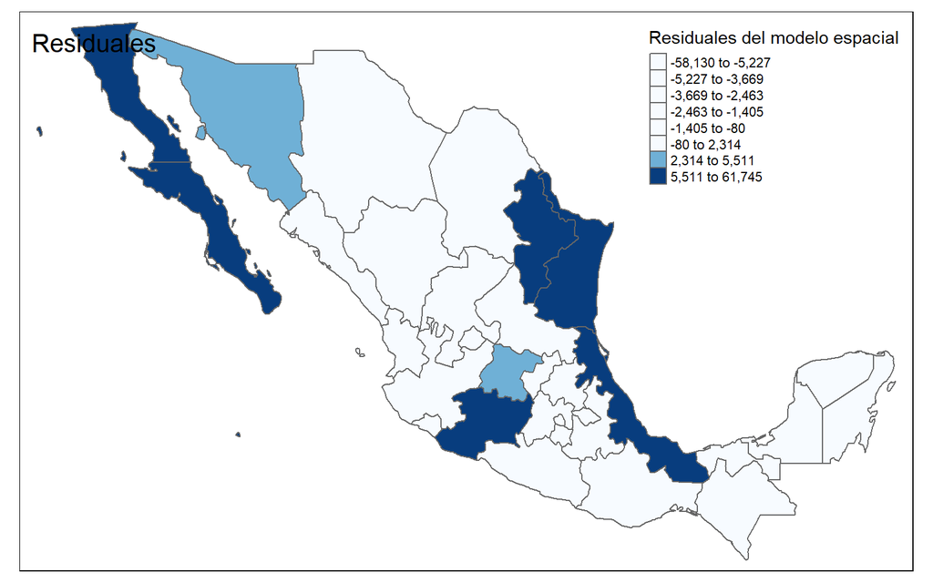

```r
spatial <- tm_shape(unidos) +
  tm_polygons(col = "spatial_residuals", palette="Blues", style="quantile", n=8, title="Residuales del modelo espacial") +tm_layout(title="Residuales")
spatial
```

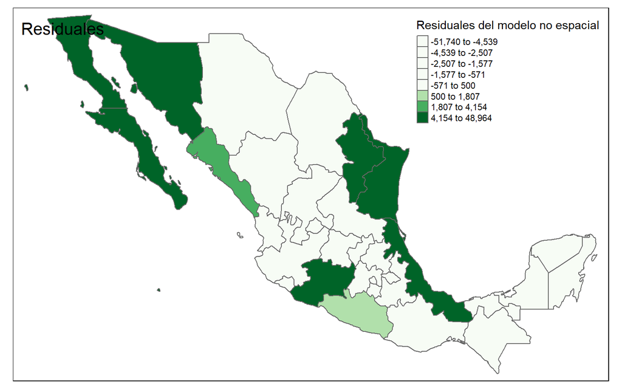

```r
non_spatial <- tm_shape(unidos) +
  tm_polygons(col = "non_spatial_residuals", palette="Greens", style="quantile", n=8, title="Residuales del modelo no espacial") + tm_layout(title="Residuales")
non_spatial
```